# HW 3 - Case Study: Welcome to University

Group NYC - BDA 503 - Fall 2017

Our group’s analysis about the position of MEF University in the YGS/LYS exam of 2017 is below:

#### Analysis 1

– At first, we created a table called ‘mef’ which shows the average minimum and average maximum entrance scores of MEF University according to the exam types.

```r
mef=osym_data_2017 %>%
  filter(university_name=='MEF ÜNİVERSİTESİ') %>%
  group_by(exam_type) %>%
  summarise('Avg Min Score (MEF)'=mean(min_score),'Avg Max Score (MEF)'=mean(max_score))
mef
```

```
## # A tibble: 5 x 3
##   exam_type `Avg Min Score (MEF)` `Avg Max Score (MEF)`
##       <chr>                 <dbl>                 <dbl>
## 1     DİL_1              391.4231              442.3467
## 2      MF_1              328.7309              372.3632
## 3      MF_4              342.1534              382.3247
## 4      TM_1              284.4810              347.3462
## 5      TM_3              362.6865              405.2485
```

– Then, we created a table called ‘toplam’ which shows the average minimum and average maximum entrance scores of all universities in Turkey according to the exam types which is accepted by MEF University.

```r
toplam=osym_data_2017 %>% filter(exam_type=='MF_1' | exam_type=='DİL_1'| exam_type=='TM_3'| exam_type=='TM_1'| exam_type=='MF_4') %>% group_by(exam_type) %>% summarise('Avg Min Score (All)'=mean(min_score),'Avg Max Score (All)'=mean(max_score))
toplam
```

```
## # A tibble: 5 x 3
##   exam_type `Avg Min Score (All)` `Avg Max Score (All)`
##       <chr>                 <dbl>                 <dbl>
## 1     DİL_1              340.2905              402.0751
## 2      MF_1              278.0457              327.2451
## 3      MF_4              292.9153              328.0737
## 4      TM_1              249.1664              288.1021
## 5      TM_3              311.3365              353.2401
```

– In the 3rd, step we joined table mef and total under the name of data_final

```r
data_final=full_join(mef,toplam,by='exam_type')
data_final
```

```
## # A tibble: 5 x 5
##   exam_type `Avg Min Score (MEF)` `Avg Max Score (MEF)`
##       <chr>                 <dbl>                 <dbl>
## 1     DİL_1              391.4231              442.3467
## 2      MF_1              328.7309              372.3632
## 3      MF_4              342.1534              382.3247
## 4      TM_1              284.4810              347.3462
## 5      TM_3              362.6865              405.2485
## # ... with 2 more variables: `Avg Min Score (All)` <dbl>, `Avg Max Score
## #   (All)` <dbl>
```

– In the 4th step, we melted data_final table

```r
df=melt(data_final,id.vars=1)
df
```

```
##    exam_type            variable    value
## 1      DİL_1 Avg Min Score (MEF) 391.4231
## 2       MF_1 Avg Min Score (MEF) 328.7309
## 3       MF_4 Avg Min Score (MEF) 342.1534
## 4       TM_1 Avg Min Score (MEF) 284.4810
## 5       TM_3 Avg Min Score (MEF) 362.6865
## 6      DİL_1 Avg Max Score (MEF) 442.3467
## 7       MF_1 Avg Max Score (MEF) 372.3632
## 8       MF_4 Avg Max Score (MEF) 382.3247
## 9       TM_1 Avg Max Score (MEF) 347.3462
## 10      TM_3 Avg Max Score (MEF) 405.2485
## 11     DİL_1 Avg Min Score (All) 340.2905
## 12      MF_1 Avg Min Score (All) 278.0457
## 13      MF_4 Avg Min Score (All) 292.9153
## 14      TM_1 Avg Min Score (All) 249.1664
## 15      TM_3 Avg Min Score (All) 311.3365
## 16     DİL_1 Avg Max Score (All) 402.0751
## 17      MF_1 Avg Max Score (All) 327.2451
## 18      MF_4 Avg Max Score (All) 328.0737
## 19      TM_1 Avg Max Score (All) 288.1021
## 20      TM_3 Avg Max Score (All) 353.2401
```

–In the end, we drawed 2 charts; one chart for minimum scores and one chart for maximum scores

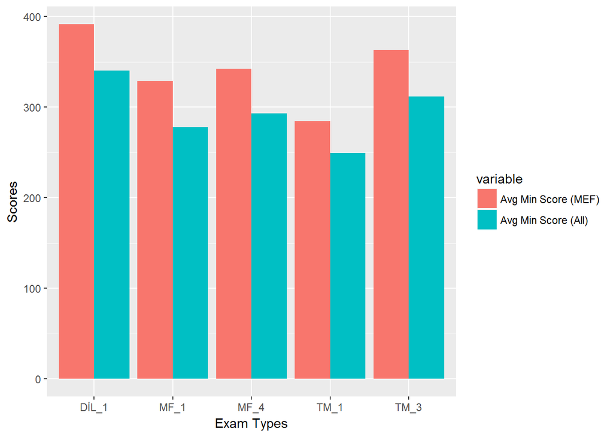

```r
ggplot(df %>% filter(substr(variable,5,7)=="Min") ,aes(x=exam_type,y=value))+
  geom_bar(aes(fill=variable),stat="identity",position="dodge")+
  ylab('Scores')+
  xlab('Exam Types')
```

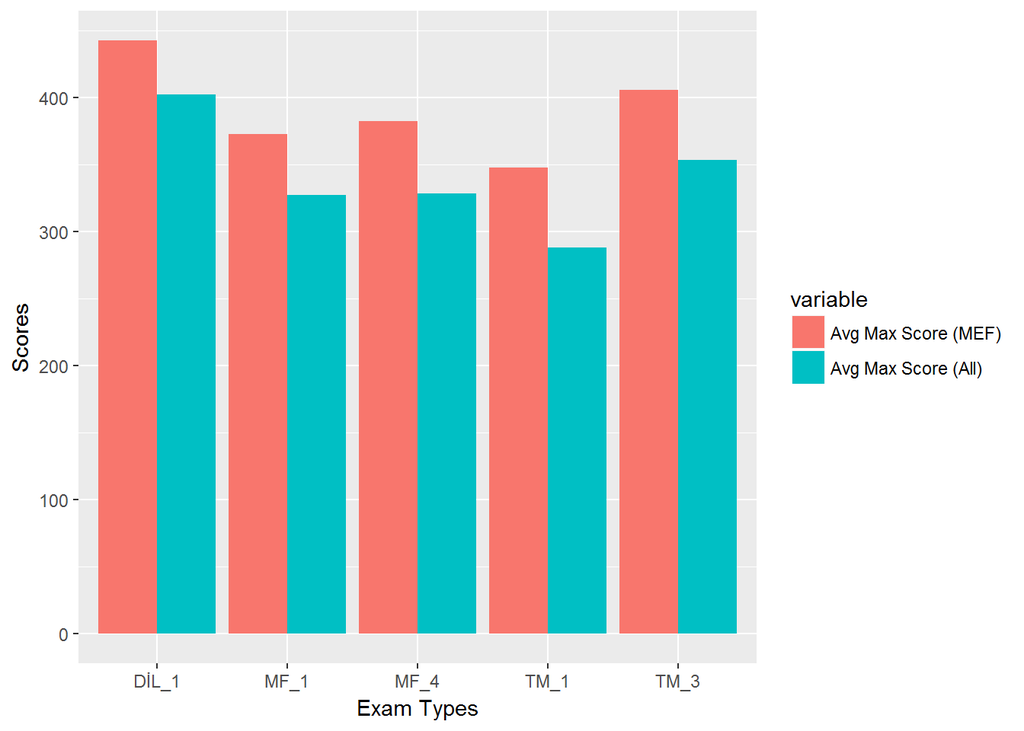

```r
ggplot(df %>% filter(substr(variable,5,7)=="Max") ,aes(x=exam_type,y=value))+
  geom_bar(aes(fill=variable),stat="identity",position="dodge")+
  ylab('Scores')+
  xlab('Exam Types')
```

#### Conclusion for Analysis 1

The avarage minimum and maximum scores of students who entered to MEF University in 2017 is higher in all exam types than the avarage minimum and maximum scores of students who entered to all universities in Turkey in 2017.

#### Analysis 2

– In the beginning, we sorted the whole data by minimum score in descending order for exam types which are accepted by MEF Unversity. Then, we gave a number according to the sorted order.

```r
siraliMF1=arrange((osym_data_2017 %>% filter(exam_type=='MF_1')),desc(min_score)) %>% mutate(sira=row_number())
siraliDIL1=arrange((osym_data_2017 %>% filter(exam_type=='DİL_1')),desc(min_score)) %>% mutate(sira=row_number())
siraliTM3=arrange((osym_data_2017 %>% filter(exam_type=='TM_3')),desc(min_score)) %>% mutate(sira=row_number())
siraliTM1=arrange((osym_data_2017 %>% filter(exam_type=='TM_1')),desc(min_score)) %>% mutate(sira=row_number())
siraliMF4=arrange((osym_data_2017 %>% filter(exam_type=='MF_4')),desc(min_score)) %>% mutate(sira=row_number())
```

–Then we created tables for each exam types filtered for MEF University which includes order number of the program name.

```r
MEFMF1=filter(siraliMF1, university_name == "MEF ÜNİVERSİTESİ")
MEFDIL1=filter(siraliDIL1, university_name == "MEF ÜNİVERSİTESİ")
MEFTM3=filter(siraliTM3, university_name == "MEF ÜNİVERSİTESİ")
MEFTM1=filter(siraliTM1, university_name == "MEF ÜNİVERSİTESİ")
MEFMF4=filter(siraliMF4, university_name == "MEF ÜNİVERSİTESİ")
```

– The Plot Graph of the Order MEF University’s Programs Which Accepts MF_1 Score

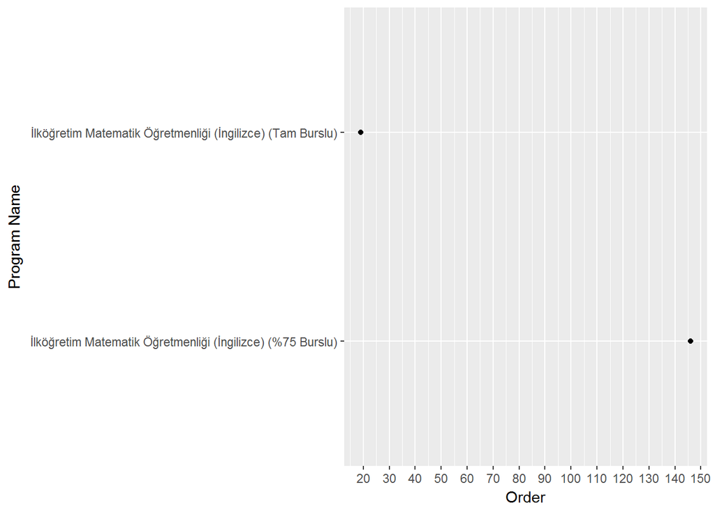

```r
ggplot(MEFMF1, aes(sira,program_name),e)+
  geom_point()+
  scale_x_continuous(breaks=seq(0,1000,10))+
  xlab('Order')+
  ylab('Program Name')
```

– The Plot Graph of the Order MEF University’s Programs Which Accepts DİL_1 Score

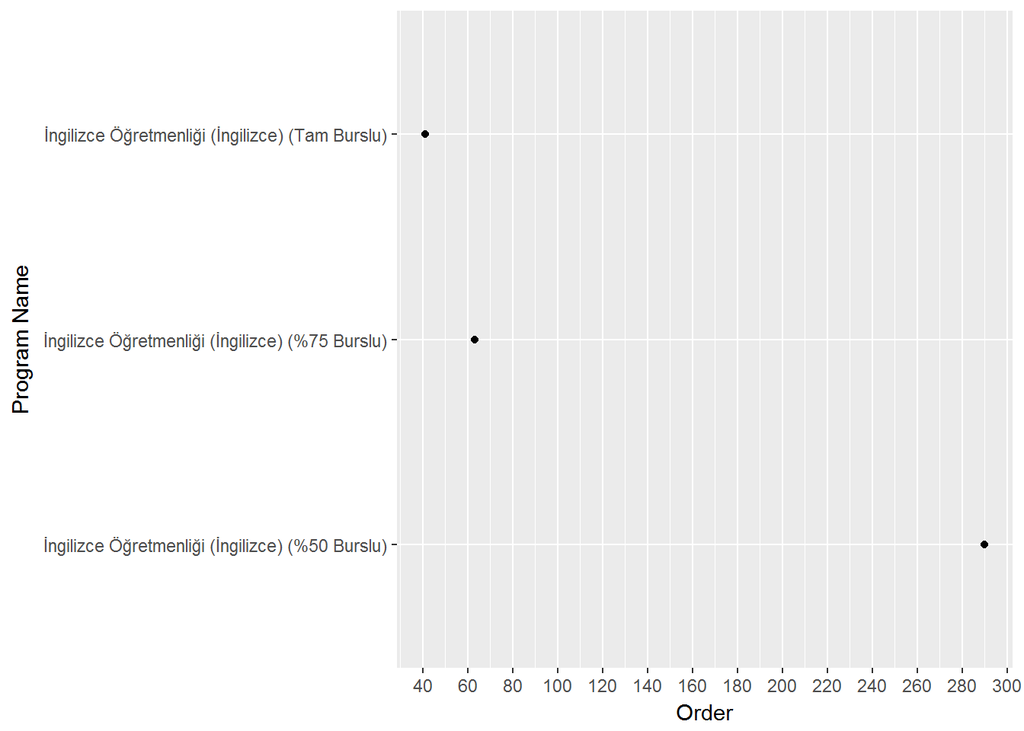

```r
ggplot(MEFDIL1, aes(sira,program_name),e)+
  geom_point()+
  scale_x_continuous(breaks=seq(0,1000,20))+
  xlab('Order')+
  ylab('Program Name')
```

– The Plot Graph of the Order MEF University’s Programs Which Accepts TM_3 Score

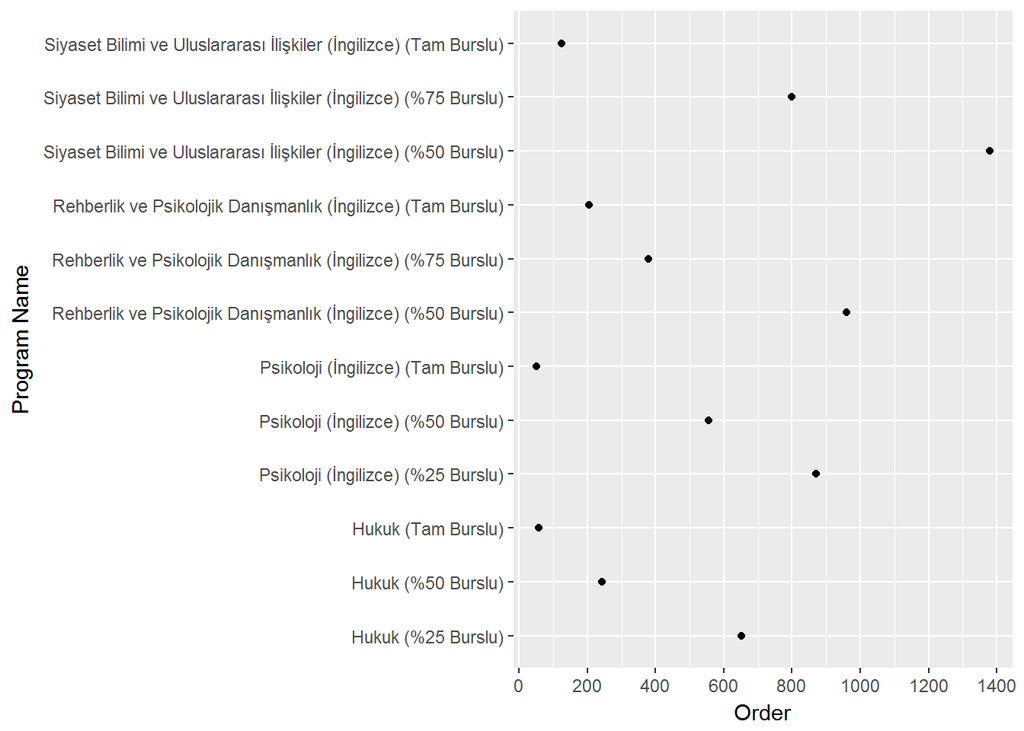

```r
ggplot(MEFTM3, aes(sira,program_name),e)+
  geom_point()+
  scale_x_continuous(breaks=seq(0,1600,200))+
  xlab('Order')+
  ylab('Program Name')
```

– The Plot Graph of the Order MEF University’s Programs Which Accepts TM_1 Score

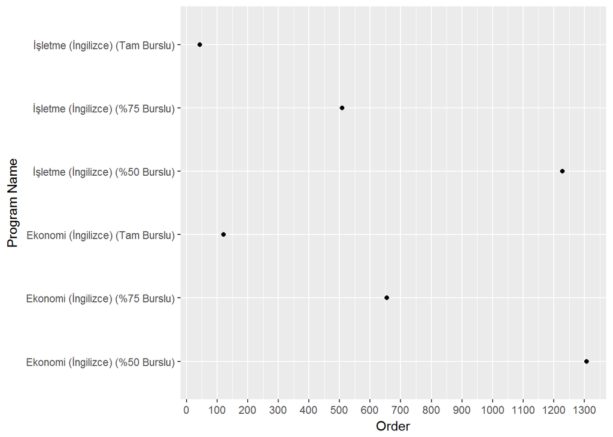

```r
ggplot(MEFTM1, aes(sira,program_name),e)+
  geom_point()+
  scale_x_continuous(breaks=seq(0,10000,100))+
  xlab('Order')+
  ylab('Program Name')
```

– The Plot Graph of the Order MEF University’s Programs Which Accepts MF4 Score

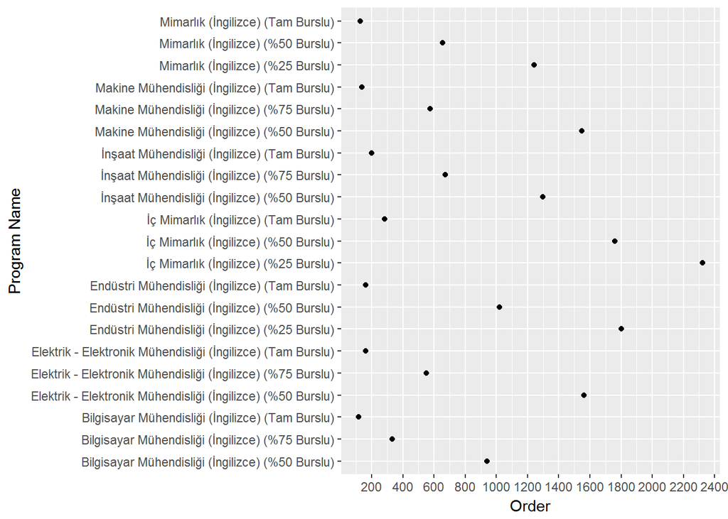

```r
ggplot(MEFMF4, aes(sira,program_name),e)+
  geom_point()+
  scale_x_continuous(breaks=seq(0,10000,200))+
  xlab('Order')+
  ylab('Program Name')
```